# Tucker Carlson’s Audience: Combined Analysis

PrimePanels + Connect Samples — Merged Dataset

Published

February 18, 2026

**WarningPilot Data — Treat All Results as Preliminary**

This report combines **213 completed responses** across two data sources: **122 from PrimePanels** and **91 from Connect** (CloudResearch). Both datasets were collected in February 2026 as pilot studies. Statistical results should be treated as exploratory pending full-scale replication.

**NoteHow the Two Sources Were Combined**

| Feature | PrimePanels | Connect |
| --- | --- | --- |
| Recruitment | PrimePanels panel | CloudResearch Connect |
| Post-treatment Q numbers | Q18–Q22 | Q17–Q21 |
| Age variable | Survey-asked (category) | Panel-provided (numeric) |
| Party variable | Survey Q31 | Panel-provided |
| Ideology variable | Survey Q30 | Survey Q29 |
| N completed | 122 | 91 |

Post-treatment column numbers were harmonised at load time so that pre–post comparisons use the correct question pairs for each respondent’s source.

# 1 Sample Overview

Table 1: Sample composition by data source

| Source | Total rows | Completed | Completion % |
| --- | --- | --- | --- |
| PrimePanels | 270 | 122 | 45% |
| Connect | 106 | 91 | 86% |
| **Total** | 376 | 213 | 57% |

# 2 Sample Characteristics

## 2.1 Demographics by Source

[figure not shown]

Figure 1: Age group distribution by source. PrimePanels age is survey-asked (categorical); Connect age is panel-provided (converted to groups).

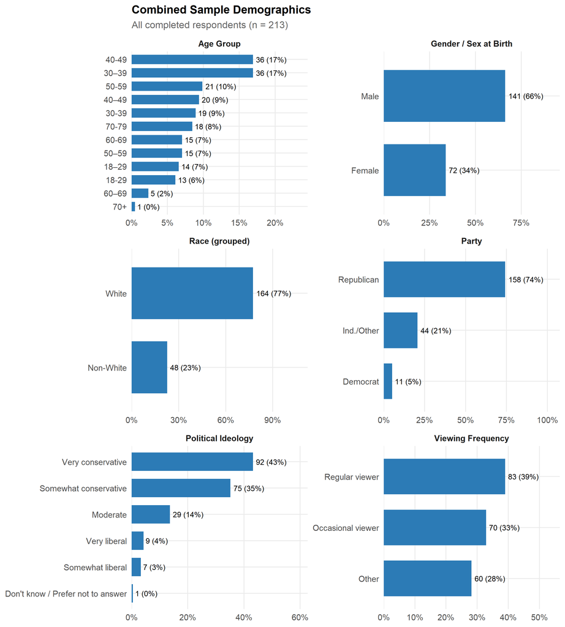

Figure 2: Demographic profile of all completed respondents (both sources combined)

## 2.2 Political Composition by Source

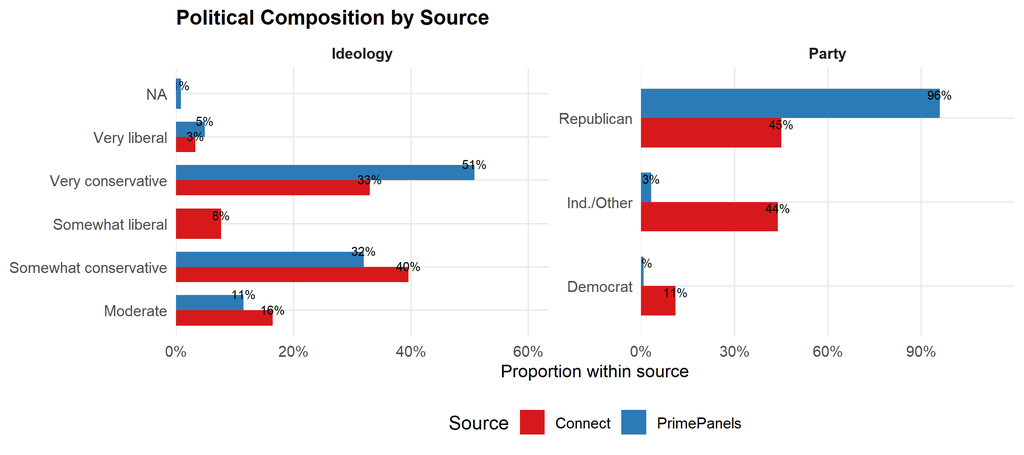

Figure 3: Party and ideology distributions by source

Table 2: Demographic summary by source and combined

| Source | n completed | % Republican | % Democrat | % Ind./Other | % Conservative | % White | Mean age (Connect) |
| --- | --- | --- | --- | --- | --- | --- | --- |
| PrimePanels | 122 | 96% | 1% | 3% | 83% | 75% | NA |
| Connect | 91 | 45% | 11% | 44% | 73% | 81% | 41.1 |
| **Combined** | 213 | 74% | 5% | 21% | 78% | 77% | 41.1 |

Conservative = Very or Somewhat conservative. Mean age uses Connect numeric age only (PrimePanels age is categorical).

# 3 Tucker Carlson Engagement

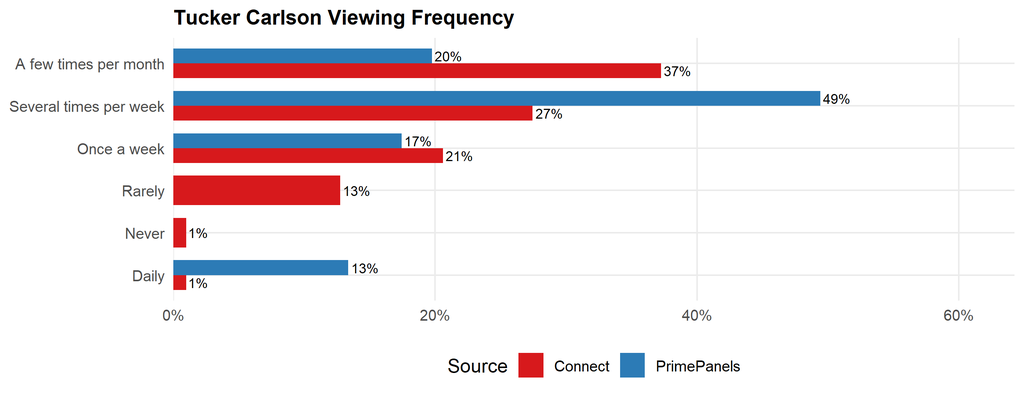

Figure 4: Viewing frequency by source (survey Q3)

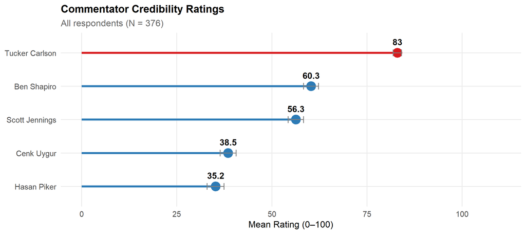

Figure 5: Commentator credibility ratings (0 = should be ignored, 100 = should be listened to)

# 4 Baseline Beliefs and Attitudes

## 4.1 Conspiracy and Fringe Beliefs

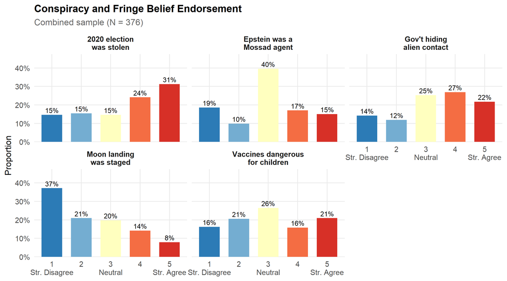

Figure 6: Conspiracy / fringe belief endorsement (Q7, 1–5 scale)

## 4.2 Foreign Policy Views (Pre-Treatment)

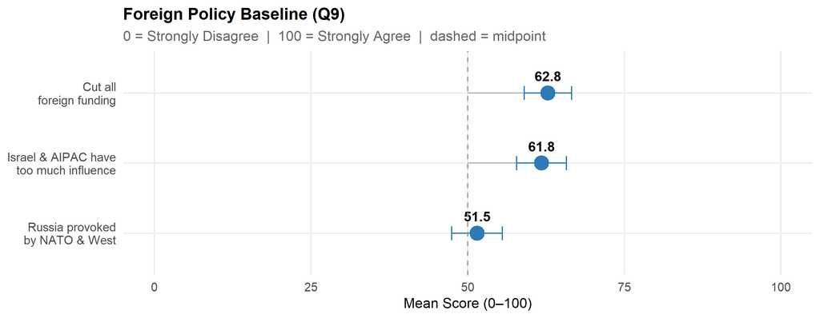

Figure 7: Foreign policy baseline attitudes (Q9, 0–100)

## 4.3 Feeling Thermometers (Pre-Treatment)

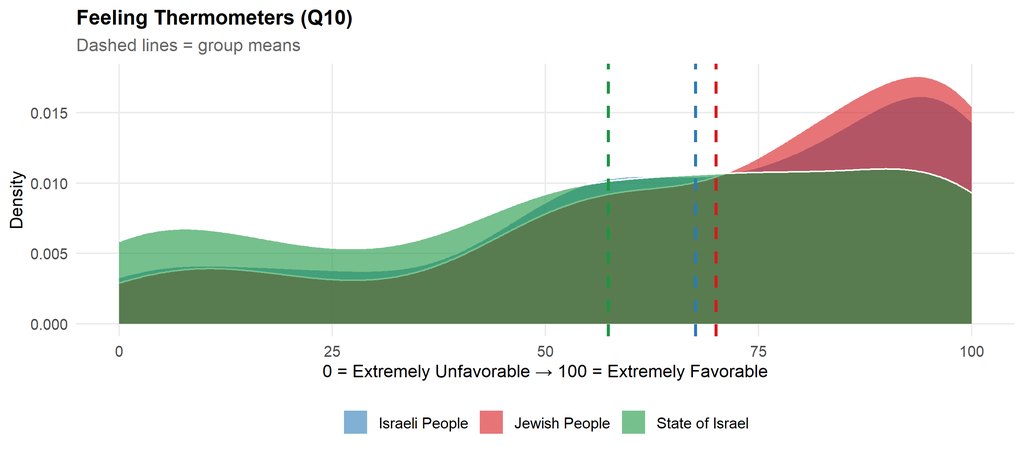

Figure 8: Feeling thermometers toward Israel and Jewish people (Q10, 0–100)

Feeling thermometer descriptives (pre-treatment, combined sample)

| item | M | SD | Md | N |
| --- | --- | --- | --- | --- |
| Israeli People | 67.6 | 29.8 | 75 | 247 |
| Jewish People | 70.0 | 29.0 | 79 | 247 |
| State of Israel | 57.4 | 32.5 | 62 | 247 |

# 5 Pre- to Post-Treatment Attitude Changes

> Post-treatment batteries: **Q18–Q22 for PrimePanels**, **Q17–Q21 for Connect**. Canonical post columns were created at load time so that each respondent’s change is computed using the correct question for their source.

## 5.1 Carlson Credibility

Table 3: Tucker Carlson credibility: pre (Q8) vs. post

Carlson Credibility (0–100)

| Item | n | Pre M | Post M | Δ | d | p |
| --- | --- | --- | --- | --- | --- | --- |
| Trusts his foreign policy analysis | 213 | 75.4 | 70.1 | -5.3 | -0.26 | 0.000 *** |
| He almost always gets the facts right | 213 | 74.8 | 68.0 | -6.8 | -0.33 | 0.000 *** |
| His predictions are usually accurate | 213 | 72.7 | 67.5 | -5.2 | -0.27 | 0.000 *** |
| Covers important topics others ignore | 213 | 85.0 | 80.4 | -4.6 | -0.22 | 0.001 ** |
| Effectively challenges mainstream narratives | 213 | 84.5 | 81.2 | -3.3 | -0.17 | 0.014 * |
| He often gets things wrong | 213 | 29.4 | 38.6 | +9.2 | 0.37 | 0.000 *** |

0–100 scales. d = Cohen's d. † p<.10, * p<.05, ** p<.01, *** p<.001.

## 5.2 Foreign Policy Views

Table 4: Foreign policy views: pre (Q9) vs. post

Foreign Policy Views (0–100)

| Item | n | Pre M | Post M | Δ | d | p |
| --- | --- | --- | --- | --- | --- | --- |
| Russia was provoked by NATO and the West | 213 | 51.2 | 53.0 | +1.8 | 0.09 | 0.186 |
| Israel and AIPAC have too much influence over America | 213 | 62.1 | 62.1 | 0 | 0.00 | 0.989 |
| We should cut all funding to foreign countries | 213 | 61.8 | 58.3 | -3.5 | -0.17 | 0.016 * |

0–100 scales. d = Cohen's d. † p<.10, * p<.05, ** p<.01, *** p<.001.

## 5.3 Feeling Thermometers

Table 5: Feeling thermometers: pre (Q10) vs. post

Feeling Thermometers (0–100)

| Item | n | Pre M | Post M | Δ | d | p |
| --- | --- | --- | --- | --- | --- | --- |
| Israeli people | 213 | 67.0 | 68.0 | +1 | 0.07 | 0.321 |
| Jewish people | 213 | 69.2 | 70.2 | +1 | 0.07 | 0.302 |
| The State of Israel | 213 | 56.2 | 57.0 | +0.8 | 0.05 | 0.448 |

0–100 scales. d = Cohen's d. † p<.10, * p<.05, ** p<.01, *** p<.001.

## 5.4 Tucker Carlson’s Israel Commentary

Table 6: Perceptions of Tucker Carlson’s Israel commentary: pre (Q11) vs. post

Carlson on Israel (0–100)

| Item | n | Pre M | Post M | Δ | d | p |
| --- | --- | --- | --- | --- | --- | --- |
| His commentary on Israel is accurate and fair | 213 | 74.6 | 67.3 | -7.3 | -0.33 | 0.000 *** |
| He asks the right questions about America's relationship with Israel | 213 | 79.8 | 74.9 | -4.9 | -0.25 | 0.000 *** |
| He is too critical of Israel | 213 | 37.0 | 41.6 | +4.6 | 0.22 | 0.002 ** |
| He understands the Middle East better than most commentators | 213 | 74.1 | 68.5 | -5.6 | -0.25 | 0.000 *** |

0–100 scales. d = Cohen's d. † p<.10, * p<.05, ** p<.01, *** p<.001.

## 5.5 Israel Policy Positions

Table 7: Israel policy views: pre (Q12) vs. post

Israel Policy Views (0–100)

| Item | n | Pre M | Post M | Δ | d | p |
| --- | --- | --- | --- | --- | --- | --- |
| The U.S.–Israel relationship benefits the United States | 213 | 57.0 | 58.3 | +1.3 | 0.06 | 0.363 |
| Israel has a legitimate right to exist as a Jewish state | 213 | 71.0 | 71.1 | +0.1 | 0.00 | 0.948 |
| Israel generally acts morally in its self-defense | 213 | 56.5 | 58.9 | +2.4 | 0.13 | 0.068 † |
| The U.S. should reduce military aid to Israel | 213 | 60.8 | 60.5 | -0.2 | -0.01 | 0.879 |

0–100 scales. d = Cohen's d. † p<.10, * p<.05, ** p<.01, *** p<.001.

## 5.6 Summary: Forest Plot of All Pre/Post Changes

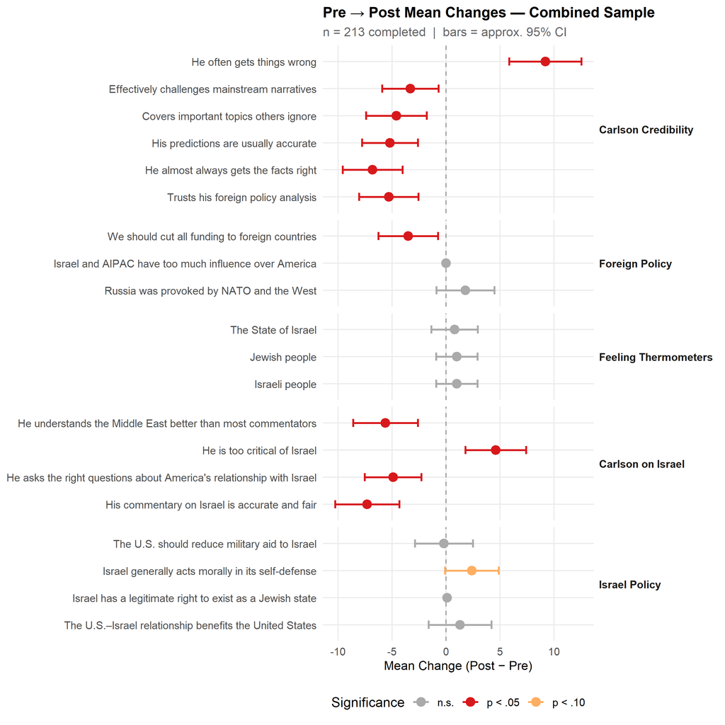

Figure 9: All 20 pre–post mean changes with approximate 95% CIs. Red = p < .05; orange = p < .10.

## 5.7 Pre/Post Changes by Source

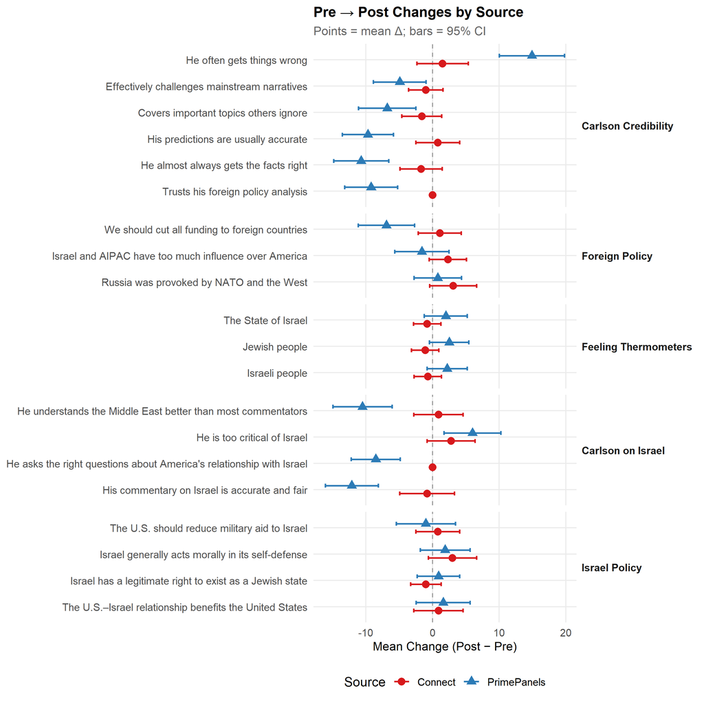

Figure 10: Mean pre–post change by source (PrimePanels vs. Connect). Points = mean Δ; bars = 95% CI.

# 6 Audience Segmentation (Baseline Clusters)

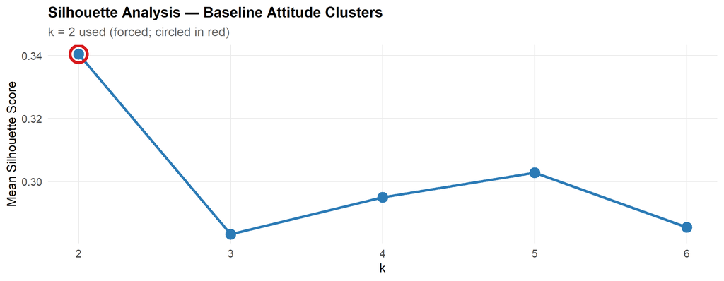

Figure 11: Silhouette analysis: k = 2 used for narrative consistency

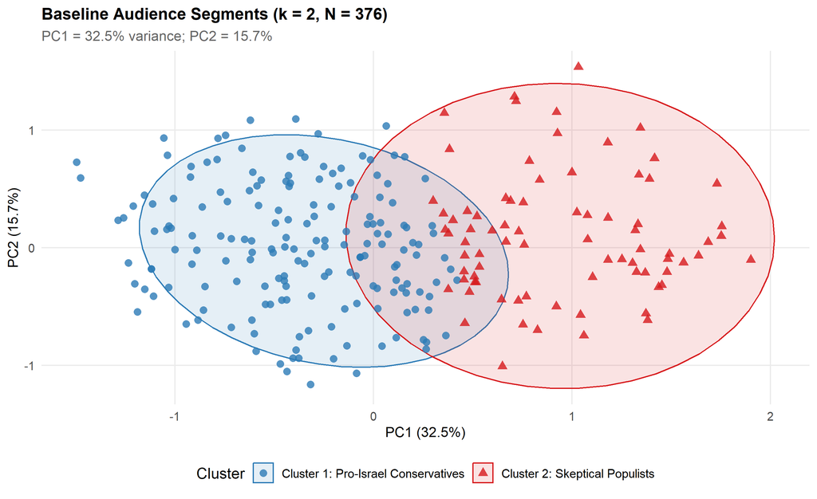

Figure 12: Baseline audience clusters projected onto first two principal components

Table 8: Baseline cluster mean profiles across all attitude dimensions (completed respondents)

Cluster Profiles: Cluster 1 (n=140) vs. Cluster 2 (n=73)

| Item | Cluster 1 (n=140) | Cluster 2 (n=73) |
| --- | --- | --- |
| **Conspiracy Beliefs (1–5 scale)** |  |  |
| Vaccines dangerous | 2.8 | 3.5 |
| Moon landing staged | 2.0 | 3.0 |
| Epstein/Mossad | 2.6 | 3.8 |
| Gov't hiding alien contact | 3.0 | 3.8 |
| 2020 election stolen | 3.3 | 3.4 |
| **Foreign Policy (0–100)** |  |  |
| Russia provoked by NATO | 44.5 | 64.0 |
| Israel/AIPAC too influential | 47.9 | 89.3 |
| Cut all foreign funding | 55.5 | 73.8 |
| **Feeling Thermometers (0–100)** |  |  |
| Israeli people (therm.) | 81.3 | 39.5 |
| Jewish people (therm.) | 81.1 | 46.5 |
| State of Israel (therm.) | 74.3 | 21.4 |
| **Carlson on Israel (0–100)** |  |  |
| Commentary accurate & fair | 72.8 | 77.9 |
| Asks right questions | 78.4 | 82.5 |
| Too critical of Israel | 46.6 | 18.6 |
| Understands Middle East | 75.1 | 72.3 |
| **Israel Policy (0–100)** |  |  |
| US-Israel benefits US | 73.7 | 24.9 |
| Israel right to exist | 85.0 | 44.3 |
| Israel acts morally | 73.6 | 23.8 |
| Reduce military aid | 46.7 | 87.8 |

Conspiracy: 1=Str. Disagree, 5=Str. Agree. Others: 0–100 sliders.

## 6.1 Cluster Demographics and Source Composition

Table 9: Demographic and source composition by baseline cluster

| Cluster | n | % PrimePanels | % Connect | % Republican | % Democrat | % Conservative | Mean Age |
| --- | --- | --- | --- | --- | --- | --- | --- |
| 1 | 140 | 68% | 32% | 84% | 4% | 84% | 42.0 |
| 2 | 73 | 37% | 63% | 55% | 7% | 68% | 40.3 |

Mean Age uses Connect numeric age only. % PrimePanels + % Connect ≈ 100%.

[figure not shown]

Figure 13: Cluster membership proportions by source

# 7 Change Score Analysis

## 7.1 Change Score Distributions

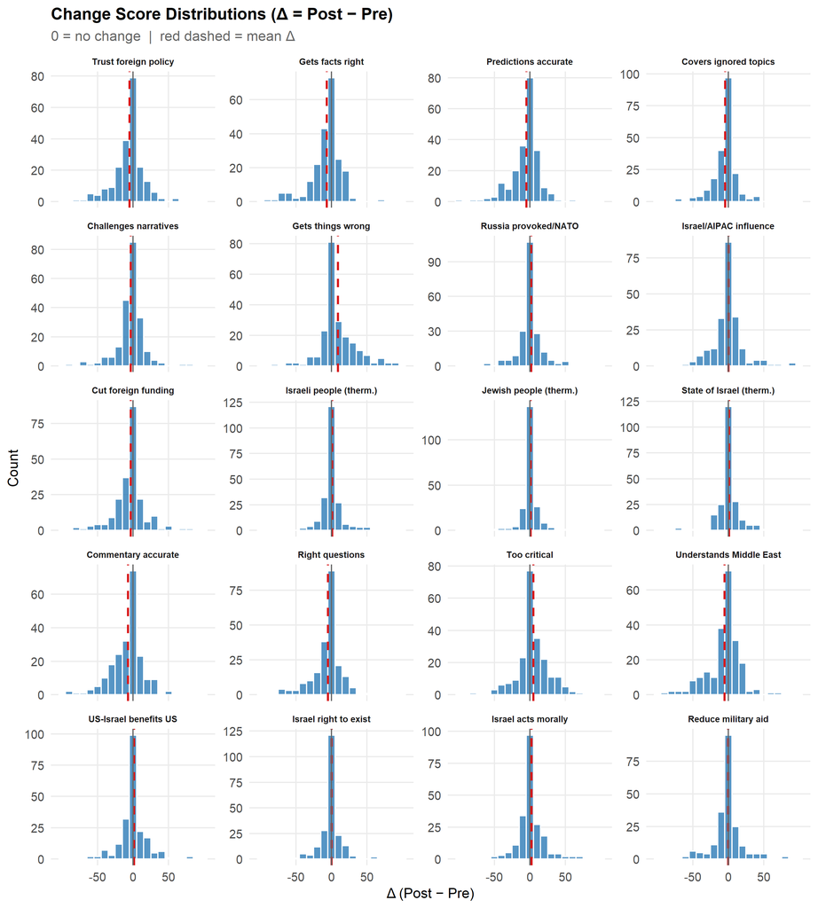

Figure 14: Distribution of pre-to-post change scores for all 20 items. Red dashed = mean Δ.

Table 10: Change score summary statistics for all outcome items

| Domain | Item | n | Mean Δ | SD | % Δ>0 | % Δ<0 |
| --- | --- | --- | --- | --- | --- | --- |
| Carlson Credibility | Trust foreign policy | 213 | -5.3 | 20.6 | 34% | 56% |
|  | Gets facts right | 213 | -6.8 | 20.9 | 34% | 54% |
|  | Predictions accurate | 213 | -5.2 | 19.5 | 41% | 47% |
|  | Covers ignored topics | 213 | -4.6 | 20.7 | 29% | 50% |
|  | Challenges narratives | 213 | -3.3 | 19.4 | 33% | 52% |
|  | Gets things wrong | 213 | 9.2 | 25.1 | 58% | 31% |
| Foreign Policy | Russia provoked/NATO | 213 | 1.8 | 19.6 | 40% | 39% |
|  | Israel/AIPAC influence | 213 | 0.0 | 20.7 | 38% | 44% |
|  | Cut foreign funding | 213 | -3.5 | 20.9 | 34% | 50% |
| Feeling Thermometers | Israeli people (therm.) | 213 | 1.0 | 14.1 | 39% | 34% |
|  | Jewish people (therm.) | 213 | 1.0 | 13.8 | 45% | 30% |
|  | State of Israel (therm.) | 213 | 0.8 | 14.9 | 42% | 30% |
| Carlson on Israel | Commentary accurate | 213 | -7.3 | 21.8 | 36% | 57% |
|  | Right questions | 213 | -4.9 | 19.8 | 37% | 50% |
|  | Too critical | 213 | 4.6 | 21.2 | 53% | 33% |
|  | Understands Middle East | 213 | -5.6 | 22.6 | 38% | 48% |
| Israel Policy | US-Israel benefits US | 213 | 1.3 | 20.4 | 37% | 41% |
|  | Israel right to exist | 213 | 0.1 | 14.8 | 31% | 37% |
|  | Israel acts morally | 213 | 2.4 | 18.8 | 40% | 37% |
|  | Reduce military aid | 213 | -0.2 | 22.9 | 37% | 41% |

% Δ>0 = proportion who increased; % Δ<0 = proportion who decreased.

## 7.2 Change by Baseline Attitude Cluster

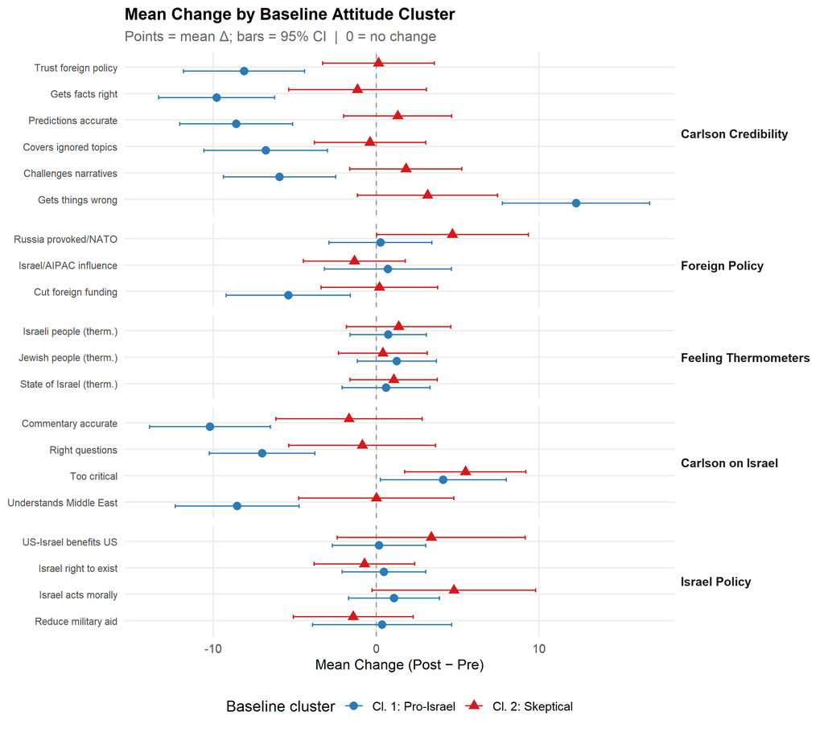

Figure 15: Mean change score by baseline cluster

## 7.3 Cluster Analysis on Change Scores

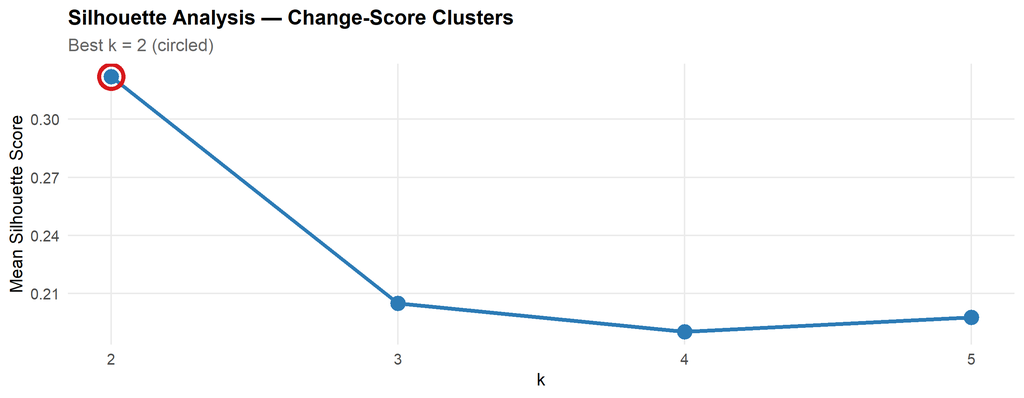

Figure 16: Silhouette analysis for change-score clusters

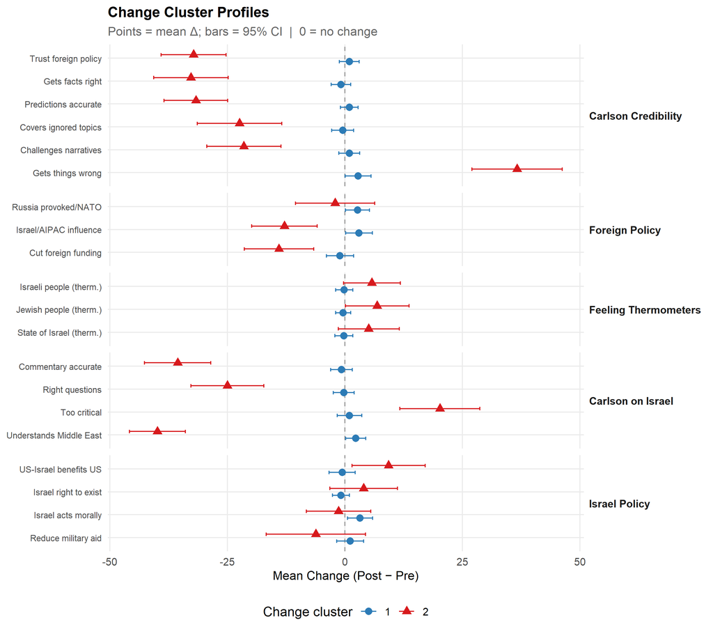

Figure 17: Change cluster profiles across all 20 outcome items

Table 11: Mean Δ by change cluster for all 20 outcome items

Mean Δ by Change Cluster (k = 2)

| Domain | Item | Cluster 1 (n=173) | Cluster 2 (n=40) |
| --- | --- | --- | --- |
| Carlson Credibility | Trust foreign policy | 0.9 | -32.2 |
|  | Gets facts right | -0.8 | -32.8 |
|  | Predictions accurate | 0.9 | -31.7 |
|  | Covers ignored topics | -0.5 | -22.4 |
|  | Challenges narratives | 0.9 | -21.5 |
|  | Gets things wrong | 2.8 | 36.6 |
| Foreign Policy | Russia provoked/NATO | 2.7 | -2.1 |
|  | Israel/AIPAC influence | 3.0 | -12.9 |
|  | Cut foreign funding | -1.0 | -14.0 |
| Feeling Thermometers | Israeli people (therm.) | -0.2 | 5.8 |
|  | Jewish people (therm.) | -0.4 | 6.9 |
|  | State of Israel (therm.) | -0.2 | 5.1 |
| Carlson on Israel | Commentary accurate | -0.7 | -35.6 |
|  | Right questions | -0.2 | -25.0 |
|  | Too critical | 1.0 | 20.2 |
|  | Understands Middle East | 2.3 | -39.9 |
| Israel Policy | US-Israel benefits US | -0.6 | 9.3 |
|  | Israel right to exist | -0.8 | 4.0 |
|  | Israel acts morally | 3.2 | -1.4 |
|  | Reduce military aid | 1.1 | -6.2 |

Δ = post − pre. Negative = decreased; positive = increased.

Table 12: Demographic composition of change clusters

| Change Cluster | n | % PrimePanels | % Republican | % Conservative | Mean Age |
| --- | --- | --- | --- | --- | --- |
| 1 | 173 | 51% | 72% | 82% | 40.1 |
| 2 | 40 | 82% | 82% | 65% | 53.7 |

Mean Age uses Connect numeric age only.

## 7.4 Cross-Tab: Baseline × Change Clusters

Table 13: Cross-tabulation: baseline attitude cluster × change-score cluster

Cross-tab: Baseline × Change Clusters

| Baseline Cluster | Change Cl. 1 | Change Cl. 2 | Total | % in Change Cl.1 |
| --- | --- | --- | --- | --- |
| 1 | 106 | 34 | 140 | 76% |
| 2 | 67 | 6 | 73 | 92% |

Fisher's exact test: p = 0.005

# 8 Key Findings

Table 14: Summary of principal findings — combined sample

[output not shown]

# Appendix: Technical Notes

**Data sources:** `result_persuasion_PrimePanels_2.17.26.csv`, `result_persuasion_PrimePanels_N91.17.27.csv`, and `result_persuasion_Connect_2.17.26.csv`. The two PrimePanels files are combined with `distinct()` to remove any exact duplicate rows that may exist if the newer export is cumulative.

**Post-treatment harmonisation:** Connect uses Q17–Q21 for post-treatment batteries; PrimePanels uses Q18–Q22. Canonical `post_<domain>_<i>` columns were created at load time using `if_else(source == "PrimePanels", ...)` to select the correct column for each row.

**Clustering:** K-means with 50 random starts on pre-treatment variables (Q7–Q12), which have identical question numbers in both sources. Baseline k forced to 2 for narrative consistency. Change-score k selected by silhouette. Missing change scores imputed as 0 (no change).